# Social Network Analysis

```r
library (statnet)
```

[output not shown]

```r
library (statnet)
library (intergraph)
```

## Working with networks

On this workshop, we will work with the data that represents an infamous 9/11 terrorist network. It was collected by Valdis Krebbs (2002) and consists of data on network ties among 9/11 terrorists and their node attributes (“network strength”, “ties”, “attended Las Vegas metting”).

Krebs, Valdis E. “Mapping networks of terrorist cells.” Connections 24.3 (2002): 43-52. https://www.aclu.org/sites/default/files/field_document/ACLURM002810.pdf

Node attributes are as follows:

- **Network strength:** 1 = trusted prior contacts; 2 = associates.
- **Ties:** 1 = AA #11 WTC North; 2 = AA #77 Pentagon; 3 = UA #93 Pennsylvania; 4 = UA #175 WTC South; 5 = Other Associates.
- **Las Vegas Meeting:** 1 = Attended; 0 = Did Not Attend.

Below is the code to load the data, clean it and create an adjacency matrix for the network ties.

| X | Network.Strength | Ties | Las.Vegas.Meeting |
| --- | --- | --- | --- |
| Majed Moqed | 1 | 2 | 0 |
| Khalid Al-Mihdhar | 1 | 2 | 0 |
| Hani Hanjour | 1 | 2 | 1 |
| Nawaf Alhazmi | 1 | 2 | 1 |
| Salem Alhazmi* | 1 | 2 | 1 |
| Ahmed Alnami | 1 | 3 | 0 |
| Ahmed Alghamdi | 1 | 4 | 0 |
| Saeed Alghamdi* | 1 | 3 | 0 |
| Hamza Alghamdi | 1 | 4 | 0 |
| Ahmed Al Haznawi | 1 | 3 | 0 |

[output cut: 51 more lines]

```r
colnames(mat911) %in% rownames (attr911) #check that the names of the terrorists in the matrix match the names in the node attribute data frame
```

```
 [1] TRUE TRUE TRUE TRUE TRUE TRUE TRUE TRUE TRUE TRUE TRUE TRUE TRUE TRUE
[15] TRUE TRUE TRUE TRUE TRUE TRUE TRUE TRUE TRUE TRUE TRUE TRUE TRUE TRUE
[29] TRUE TRUE TRUE TRUE TRUE TRUE TRUE TRUE TRUE TRUE TRUE TRUE TRUE TRUE
[43] TRUE TRUE TRUE TRUE TRUE TRUE TRUE TRUE TRUE TRUE TRUE TRUE TRUE TRUE
[57] TRUE TRUE TRUE TRUE TRUE
```

### Creating a network

```r
graph
```

```
IGRAPH 5473fba DN-- 61 199 --
+ attr: name (v/c)
+ edges from 5473fba (vertex names):
 [1] Majed Moqed      ->Hani Hanjour
 [2] Khalid Al-Mihdhar->Hani Hanjour
 [3] Khalid Al-Mihdhar->Nawaf Alhazmi
 [4] Hani Hanjour     ->Majed Moqed
 [5] Hani Hanjour     ->Khalid Al-Mihdhar
 [6] Hani Hanjour     ->Nawaf Alhazmi
 [7] Nawaf Alhazmi    ->Khalid Al-Mihdhar
 [8] Nawaf Alhazmi    ->Hani Hanjour
+ ... omitted several edges
```

###Adding and deleting node attributes

```r
#delete node attribute
delete_vertex_attr (graph, "ties")
```

```
IGRAPH 5473fba DN-- 61 199 --
+ attr: name (v/c)
+ edges from 5473fba (vertex names):
 [1] Majed Moqed      ->Hani Hanjour
 [2] Khalid Al-Mihdhar->Hani Hanjour
 [3] Khalid Al-Mihdhar->Nawaf Alhazmi
 [4] Hani Hanjour     ->Majed Moqed
 [5] Hani Hanjour     ->Khalid Al-Mihdhar
 [6] Hani Hanjour     ->Nawaf Alhazmi
 [7] Nawaf Alhazmi    ->Khalid Al-Mihdhar
 [8] Nawaf Alhazmi    ->Hani Hanjour
+ ... omitted several edges
```

**TASK:** try adding other node attributes (Network.Strength and Las.Vegas.Meeting) to the network.

## Plotting networks

We can plot our network using plot() function in igraph package

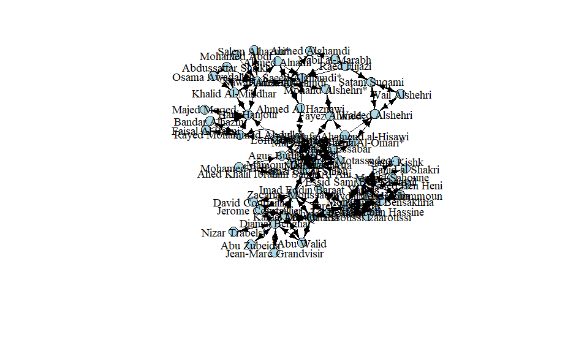

What if we want to display the nodes as belonging to different groups?

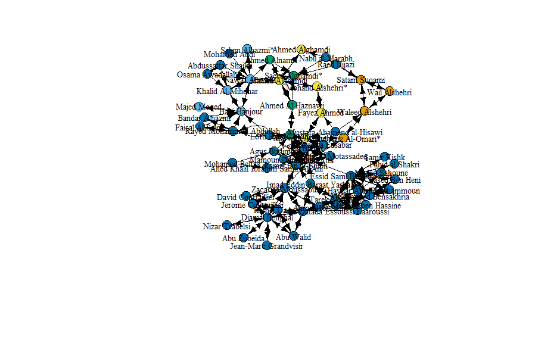

**TASK:** play with different arguments and parameters in the plot() function, such as shape or layout. Check the function’s help page: https://igraph.org/r/doc/plot.common.html

```r
#your code here:
```

## Filtering networks

Sometimes, we want to take a subset of a network. For instance, we might want to filter only terrorists who responsible for the attack on the World Trade Center (attribute “ties”, values 1 and 4).

Moreover, we need to use logical operators that are the following:

- **x & y** - x AND y (both x and y);
- **x | y** - x OR y (either x or y);
- **x==y** - x EQUALS TO y;
- **!x** - NOT x;

Relational operators (for node attributes in numeric format only):

**x<y**, **x>y**, **x<=y**, **x>=y**, **x!=y** - y greaten than x, x greater than y, y greaten than or equal to x, x greater than or eqaul to y, x not equal to y. For node attributes in numeric format, we can also use math operators, such as **+** and **-** and so on.

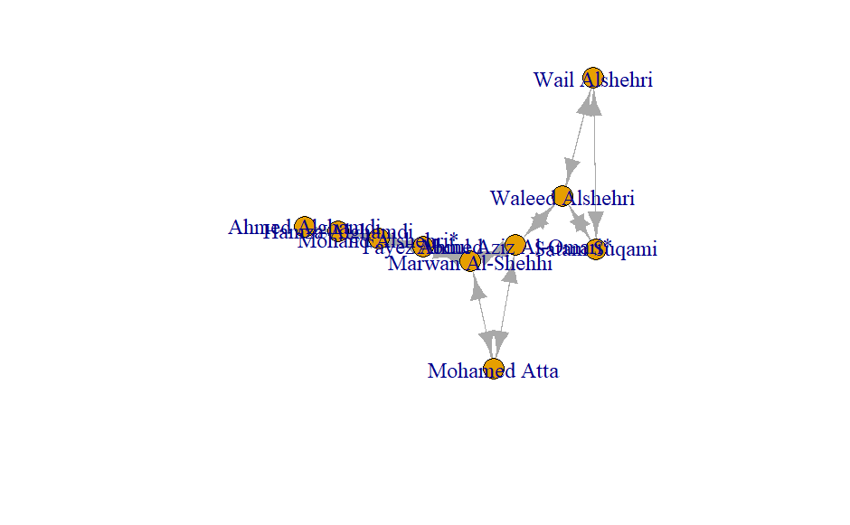

**TASK:** create a subgraph where only terrorists with network strength equals 1 are included.

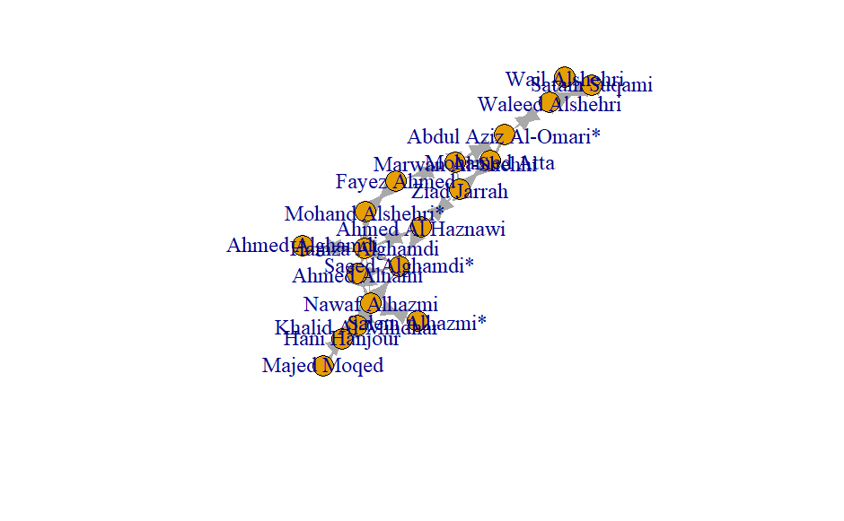

## Calculating network properties

```r
#transitivity / clustering coefficient - the proportion of closed triangles to the number of open AND closed triangles
transitivity(graph)
```

```
[1] 0.3755396
```

## Measures of centrality

Measures of centrality help us to find the most prominent and important nodes in networks.

### Degree centrality

*Degree centrality* shows how many ties each node has. The more ties a node has, the more prominent it is considered to be in a given network.

To calculate degree centrality, we can use *degree ()* function. Don’t forget to specify whether you have a directed or undirected network. Use *mode* argument if you want to calculate indegree centrality (mode = “in”) or outdegree centrality (mode = “out”).

|  | Network.Strength | Ties | Las.Vegas.Meeting |
| --- | --- | --- | --- |
| Essid Sami Ben Khemail | 2 | 5 | 0 |

### Closeness centrality

*Closeness centrality* describes how close/far each node is in relation to other nodes in the network (remember “six degrees of separation” or the idea that every person on the Earth can reach other person in just six steps on average). Nodes with high closeness centrality can reach other nodes in just a few steps, whereas nodes with low closeness centrality scores need to make many steps.

Closeness centrality for each node is calculated as number of nodes minus one (this is the hypothetical minimal sum of the shortest paths for each node) divided by the sum of the observed shortest paths between the given node and all other nodes in the network. It is expressed between 0 and 1. The higher the closeness score, the closer the node is located to other nodes in the network.

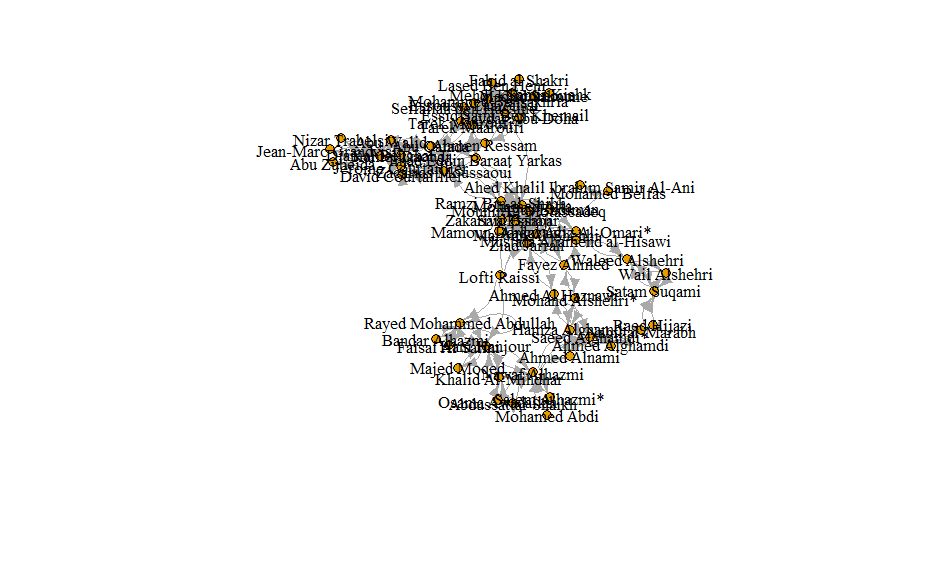

### Eigenvector centrality

*Eigenvector centrality* Recall that the nodes who have highest degree (that is, the number of ties), also have highest degree centrality. However, this does not necessarily mean that they are the most important ones - what if they have many connections to the unimportant nodes only (that have few connections to others in the network)?

We can use eigenvector centrality to figure out who the most important nodes in the network are. The nodes that have high eigenvector centrality are connected to other highly connected nodes in the network.

```r
which.max (ec)
```

```
Mohamed Atta
          15
```

### Betweenness centrality

*Betweenness centrality* is something less intuititve, however, to put it simply, nodes that have highest betweenness centrality sit in between the most of the pairs of other nodes. In other words, when other nodes will send information in the network, this information will very likely pass through these nodes with high betweenness centrality.

**TASK**: calculate betweenness centrality using function *betweenness ()*.

```r
bc
```

```
                     Majed Moqed                Khalid Al-Mihdhar
                       0.0000000                        2.0000000
                    Hani Hanjour                    Nawaf Alhazmi
                      83.5000000                      160.5000000
                  Salem Alhazmi*                     Ahmed Alnami
                       0.0000000                        0.0000000
                  Ahmed Alghamdi                  Saeed Alghamdi*
                      10.8333333                        0.0000000
                  Hamza Alghamdi                 Ahmed Al Haznawi
                     246.1666667                      225.9833333
                Mohand Alshehri*                      Fayez Ahmed
                      56.3500000                       82.8500000
                     Ziad Jarrah                 Marwan Al-Shehhi
                     252.6500000                      167.6166667
                    Mohamed Atta             Abdul Aziz Al-Omari*
                     319.4333333                      194.1666667
                 Waleed Alshehri                    Wail Alshehri
                     139.5000000                        0.0000000
                    Satam Suqami                      Raed Hijazi
                      11.1666667                        0.0000000
                 Nabil al-Marabh        Mustafa Ahamend al-Hisawi
                       5.8333333                        0.0000000
               Mamoun Darkazanli                 Zakariya Essabar
                       0.0000000                        0.0000000
                     Said Bahaji             Mounir El Motassadeq
                      60.1000000                        0.0000000
              Zacarias Moussaoui               Ramzi Bin al-Shibh
                     424.8071429                      334.0166667
                    Agus Budiman Ahed Khalil Ibrahim Samir Al-Ani
                      40.1666667                        1.8333333
                    Lofti Raissi          Rayed Mohammed Abdullah
                       0.0000000                        4.0000000
                  Bandar Alhazmi                  Faisal Al Salmi
                       0.0000000                        0.0000000
                 Osama Awadallah               Abdussattar Shaikh
                       0.0000000                        0.0000000
                    Mohamed Abdi                   Mohamed Belfas
                       0.0000000                        0.0000000
        Imad Eddin Baraat Yarkas                   Tarek Maaroufi
                      96.1666667                      276.4809524
                      Abu Qatada                   Djamal Benghal
                     259.4809524                      230.2047619
             Jerome Courtaillier               David Courtaillier
                      15.8333333                        0.0000000
                    Ahmen Ressam                        Abu Walid
                      76.5190476                       14.6666667
            Jean-Marc Grandvisir                      Abu Zubeida
                       0.0000000                        0.0000000
                  Nizar Trabelsi                  Haydar Abu Doha
                       0.0000000                       65.1023810
                  Mehdi Khammoun              Mohammed Bensakhria
                       1.0000000                       32.3238095
                  Lased Ben Heni           Essid Sami Ben Khemail
                       0.0000000                      359.4261905
           Seifallah ben Hassine               Essoussi Laaroussi
                       0.1666667                        0.1666667
                  Tarek Maaroufi                  Fahid al Shakri
                       0.0000000                        0.0000000
                  Madjid Sahoune                      Samir Kishk
                       0.0000000                        0.0000000
                    Kamel Daoudi
                      10.9880952
```

### Summing up centrality scores

Now that we’ve calculated the centrality measures, we can assemble our summary data frame that will include all centrality scores for each node.

|  | indegree | outdegree | betweenness | eigenvector | id |
| --- | --- | --- | --- | --- | --- |
| 15 | 15 | 3 | 319.4333 | 1.00 | Mohamed Atta |
| 28 | 6 | 8 | 334.0167 | 0.92 | Ramzi Bin al-Shibh |
| 14 | 12 | 4 | 167.6167 | 0.89 | Marwan Al-Shehhi |
| 25 | 4 | 7 | 60.1000 | 0.75 | Said Bahaji |
| 13 | 8 | 3 | 252.6500 | 0.72 | Ziad Jarrah |
| 27 | 7 | 7 | 424.8071 | 0.71 | Zacarias Moussaoui |
| 24 | 2 | 5 | 0.0000 | 0.60 | Zakariya Essabar |
| 54 | 11 | 11 | 359.4262 | 0.55 | Essid Sami Ben Khemail |
| 41 | 7 | 5 | 259.4810 | 0.54 | Abu Qatada |
| 26 | 2 | 4 | 0.0000 | 0.53 | Mounir El Motassadeq |

```r
#check the first ten terrorists who have the highest eigenvector centrality scores:
top10<- (head (graph_cent, 10))
top10

attr911 [rownames(attr911) %in% top10$id,]
```

|  | Network.Strength | Ties | Las.Vegas.Meeting |
| --- | --- | --- | --- |
| Ziad Jarrah | 1 | 3 | 1 |
| Marwan Al-Shehhi | 1 | 4 | 1 |
| Mohamed Atta | 1 | 1 | 1 |
| Zakariya Essabar | 2 | 5 | 0 |
| Said Bahaji | 2 | 5 | 0 |
| Mounir El Motassadeq | 2 | 5 | 0 |
| Zacarias Moussaoui | 2 | 5 | 0 |
| Ramzi Bin al-Shibh | 2 | 5 | 0 |
| Abu Qatada | 2 | 5 | 0 |
| Essid Sami Ben Khemail | 2 | 5 | 0 |

```r
NA
```

## Community detection algorithms

To identify different communities in the network, we can use various community detection algorithms. First of all, we need to transform our network into an undirected one, since some community detection algorithms work only with undirected graphs.

```r
graph_u <- as.undirected(graph)
graph_u
```

```
IGRAPH 1034c61 UN-- 61 132 --
+ attr: name (v/c), ties (v/n), la_meeting (v/n), network_strength
| (v/n)
+ edges from 1034c61 (vertex names):
 [1] Majed Moqed      --Hani Hanjour     Khalid Al-Mihdhar--Hani Hanjour
 [3] Khalid Al-Mihdhar--Nawaf Alhazmi    Hani Hanjour     --Nawaf Alhazmi
 [5] Nawaf Alhazmi    --Salem Alhazmi*   Nawaf Alhazmi    --Ahmed Alnami
 [7] Nawaf Alhazmi    --Saeed Alghamdi*  Ahmed Alnami     --Saeed Alghamdi*
 [9] Nawaf Alhazmi    --Hamza Alghamdi   Ahmed Alnami     --Hamza Alghamdi
[11] Ahmed Alghamdi   --Hamza Alghamdi   Saeed Alghamdi*  --Hamza Alghamdi
[13] Saeed Alghamdi*  --Ahmed Al Haznawi Hamza Alghamdi   --Ahmed Al Haznawi
+ ... omitted several edges
```

**Cluster_fast_greedy** is a hierarchical bottom-up algorithm that, at each step, merges two groups of nodes so that the highest modularity is achieved. It starts at the step 1, when every node in the network represents one community; on the step 2, two nodes are merged into one community so that the highest modularity is achieved. It continues merging the communities until it is no longer possible to achieve higher modularity value for the given network. As it follows from its name, this algorithm is fast and greedy, meaning that it works fast, but that smaller communities tend to be swallown up by the bigger communities (and that’s why it’s greedy).

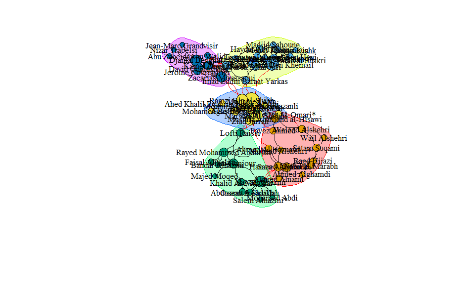

**Cluster_walktrap:** the idea behind this bottom-up algorithm is to find communities via “short random walks” (3-5 steps each), and it is based on the assumption that these walks would be performed within the given community (since there are more ties within the community than outside it). It starts from step 1 where each node represents one community and sequentially merges communities based on these random walks. It is considered to be a bit slower, but also a bit more precise algorithm than the fast and greedy algorithm.

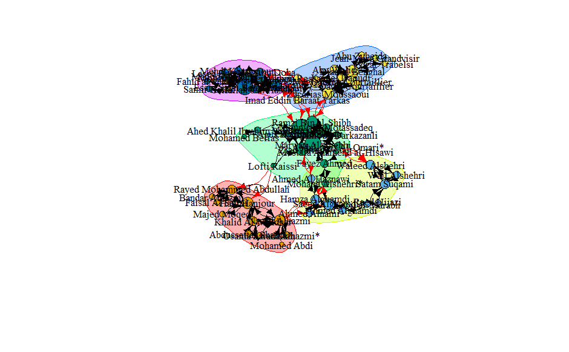

**Cluster_edge_betweenness:** it is a hierarchical top-down algorithm where edges are removed sequentially based on their edge betweenness scores (those with highest edge betweenness are removed first) and so that the highest modularity score is achieved. So, the algorithm starts with step 1, where all nodes represent one community, and then sequentially removes edges and recalculates their betweenness scores until the network falls apart into several pieces. The idea behind this is that the edges with highest betweenness scores are the most likely candidates to connect different communities within the network.This algorithm is the slowest one, but also quite accurate. NOTE: works only for undirected graphs!

```r
ceb <- cluster_edge_betweenness(graph_u)
membership (ceb)
modularity (ceb)
table (membership(ceb))

table (V(graph_u)$ties, membership(ceb))


plot (ceb, graph_u)

par(mar=c(0,0,0,0))
plot(ceb, graph_u, vertex.cex = 4, vertex.size=igraph::degree(graph_u)+6,
     vertex.label.cex = 0.7, vertex.label.color= "black", edge.curved=T,  edge.arrow.size = 0.5)
```

[output not shown]

**TASK:** try to use other community detection algorithms, such as cluster_louvain, cluster_infomap, cluster_spinglass, cluster_optimal. Compare the results.

[figure not shown]